# **Deep Learning Heart Disease Prediction**

## The Problem

The leading cause of death in the world is heart disease responsible for approximately 16% of the world's total deaths in the modern age (https://www.who.int/news-room/fact-sheets/detail/the-top-10-causes-of-death). Being able to detect heart disease before something like cardiac arrest occuring can be extremely valuable as to take preventative measures such as surgery or medicine to live a longer and healthier life. So the problem is to be able to predict heart disease in the unintrusive and affordable methods.

## The Data

In an attempt to predict heart disease in patients I will be using a heart failure prediction dataset I found on kaggle (https://www.kaggle.com/datasets/fedesoriano/heart-failure-prediction).

The data set contains 918 unique observations which have been combined from multiple sources from

- Cleveland
- Hungary
- Switzerland
- VA Long Beach

(Janosi,Andras, Steinbrunn,William, Pfisterer,Matthias, and Detrano,Robert. (1988). Heart Disease. UCI Machine Learning Repository. https://doi.org/10.24432/C52P4X.)

and Statlog dataset (Statlog (Heart). UCI Machine Learning Repository. https://doi.org/10.24432/C57303.)

The attributes include:

- Age
- Sex
- Chest Pain Type (Typical Angina, Atypical Angina, Non-Anginal Pain or Asymptomatic)
- Resting Blood Pressure
- Cholesterol
- Fasting Blood Sugar (1 if its over 120 mg/dl and 0 if not)
- Resting ECG
- Maximum Heart Rate achieved
- Exercise-Induced Angina? (Yes or No)
- Oldpeak (ST depression induced by exercise relative to rest)
- Slope of the peak exercise ST segment(upsloping, flat or downsloping)

And there is of course a label for if each observation had heart disease or not, which is what we will be trying to predict.

## The Plan

This problem is clearly a binary classification problem, does this person with these clinical data readings have heart disease or not?

I do hypothesise that the input data of the 11 attributes mentioned above will be quite sufficient in the process of predicting the output of whether the patient has heart disease or not.

In summary I plan to prepare the data, by cleaning it, encoding category strings into numbers, vectorising the data, building a suitable neural network model, train the model with a split portion of the data and then test the model with the other split portion of data. Finally I will then adjust the model parameters to maximise accuracy and minimise loss.

## Measure of Success

Considering there is an a near 50/50 split in all observations where about half have heart disease (508) and the other half does not (410). I will be using accuracy and ROC AUC as a metric for success.

## Evaluation protocol

I believe I have a fair amount of data and I will maintain a hold-out validation set, which I shall use to evaluate my model once training and parameter tuning is completed.

## Data Preparation:

```python
import pandas as pd
#load data into pandas dataframe
df = pd.read_csv('heart.csv')

df.head()
```

|  | Age | Sex | ChestPainType | RestingBP | Cholesterol | FastingBS | RestingECG | MaxHR | ExerciseAngina | Oldpeak | ST_Slope | HeartDisease |
| --- | --- | --- | --- | --- | --- | --- | --- | --- | --- | --- | --- | --- |
| 0 | 40 | M | ATA | 140 | 289 | 0 | Normal | 172 | N | 0.0 | Up | 0 |
| 1 | 49 | F | NAP | 160 | 180 | 0 | Normal | 156 | N | 1.0 | Flat | 1 |
| 2 | 37 | M | ATA | 130 | 283 | 0 | ST | 98 | N | 0.0 | Up | 0 |
| 3 | 48 | F | ASY | 138 | 214 | 0 | Normal | 108 | Y | 1.5 | Flat | 1 |
| 4 | 54 | M | NAP | 150 | 195 | 0 | Normal | 122 | N | 0.0 | Up | 0 |

```python
# encode categories into numbers
from sklearn import preprocessing

label_encoder = preprocessing.LabelEncoder()
# Males=1, Females = 0
df['Sex']= label_encoder.fit_transform(df['Sex'])

# ['ATA', 'NAP', 'ASY', 'TA']
# now maps to
# [1, 2, 0, 3]
df['ChestPainType']= label_encoder.fit_transform(df['ChestPainType'])

#Y=1 N=0
df['ExerciseAngina']= label_encoder.fit_transform(df['ExerciseAngina'])

# ['Normal', 'ST', 'LVH']
# now maps to
# [1, 2, 0]
df['RestingECG']= label_encoder.fit_transform(df['RestingECG'])

# ['Up', 'Flat', 'Down']
# now maps to
# [2, 1, 0]
df['ST_Slope']= label_encoder.fit_transform(df['ST_Slope'])

df.head()
```

|  | Age | Sex | ChestPainType | RestingBP | Cholesterol | FastingBS | RestingECG | MaxHR | ExerciseAngina | Oldpeak | ST_Slope | HeartDisease |
| --- | --- | --- | --- | --- | --- | --- | --- | --- | --- | --- | --- | --- |
| 0 | 40 | 1 | 1 | 140 | 289 | 0 | 1 | 172 | 0 | 0.0 | 2 | 0 |
| 1 | 49 | 0 | 2 | 160 | 180 | 0 | 1 | 156 | 0 | 1.0 | 1 | 1 |
| 2 | 37 | 1 | 1 | 130 | 283 | 0 | 2 | 98 | 0 | 0.0 | 2 | 0 |
| 3 | 48 | 0 | 0 | 138 | 214 | 0 | 1 | 108 | 1 | 1.5 | 1 | 1 |
| 4 | 54 | 1 | 2 | 150 | 195 | 0 | 1 | 122 | 0 | 0.0 | 2 | 0 |

```python
#Normalise the numerical values
scaler = preprocessing.StandardScaler()
numerical_cols = ["Age", "RestingBP", "Cholesterol", "MaxHR", "Oldpeak"]

df[numerical_cols] = scaler.fit_transform(df[numerical_cols])

df.head()
```

|  | Age | Sex | ChestPainType | RestingBP | Cholesterol | FastingBS | RestingECG | MaxHR | ExerciseAngina | Oldpeak | ST_Slope | HeartDisease |
| --- | --- | --- | --- | --- | --- | --- | --- | --- | --- | --- | --- | --- |
| 0 | -1.433140 | 1 | 1 | 0.410909 | 0.825070 | 0 | 1 | 1.382928 | 0 | -0.832432 | 2 | 0 |
| 1 | -0.478484 | 0 | 2 | 1.491752 | -0.171961 | 0 | 1 | 0.754157 | 0 | 0.105664 | 1 | 1 |
| 2 | -1.751359 | 1 | 1 | -0.129513 | 0.770188 | 0 | 2 | -1.525138 | 0 | -0.832432 | 2 | 0 |
| 3 | -0.584556 | 0 | 0 | 0.302825 | 0.139040 | 0 | 1 | -1.132156 | 1 | 0.574711 | 1 | 1 |
| 4 | 0.051881 | 1 | 2 | 0.951331 | -0.034755 | 0 | 1 | -0.581981 | 0 | -0.832432 | 2 | 0 |

```python
#Seperate attributes from the label
y = df["HeartDisease"]

X=df.drop("HeartDisease", axis=1)

y.head()
```

```
0    0
1    1
2    0
3    1
4    0
Name: HeartDisease, dtype: int64
```

```python
# convert dataframes into arrays
X = X.to_numpy()

X
```

```
array([[-1.4331398 ,  1.        ,  1.        , ...,  0.        ,
        -0.83243239,  2.        ],
       [-0.47848359,  0.        ,  2.        , ...,  0.        ,
         0.10566353,  1.        ],
       [-1.75135854,  1.        ,  1.        , ...,  0.        ,
        -0.83243239,  2.        ],
       ...,
       [ 0.37009972,  1.        ,  0.        , ...,  1.        ,
         0.29328271,  1.        ],
       [ 0.37009972,  0.        ,  1.        , ...,  0.        ,
        -0.83243239,  1.        ],
       [-1.64528563,  1.        ,  2.        , ...,  0.        ,
        -0.83243239,  2.        ]])
```

```python
y = y.to_numpy()

y
```

[output not shown]

[output cut: 27 more lines]

```python
#split our data into training and testing for later evaluation
from sklearn.model_selection import train_test_split
X_train, X_test, y_train, y_test = train_test_split(X, y, test_size=0.2, random_state=42)
```

## Developing a model:

First is to attempt to beat a coin flip of 50% accuracy in predicting heart disease.

```python
import tensorflow as tf
from tensorflow import keras
from keras import models
from keras import layers

# initialise the model
model_0 = models.Sequential()

#input layer with shape of the input
model_0.add(layers.Input(shape=(X_train.shape[1])))

#hidden layer with 4 output units
model_0.add(layers.Dense(8, activation='relu'))

# last layer activation as sigmoid
model_0.add(layers.Dense(1, activation='sigmoid'))

#using rmsprop optimizer
#binary crossentropy for loss (best for binary classifcation)
model_0.compile(optimizer='rmsprop', loss='binary_crossentropy', metrics=['accuracy'])

# training the model with 10 epochs and 64 batch size
history = model_0.fit(X_train, y_train, epochs=10, batch_size=64, validation_split=0.2)
```

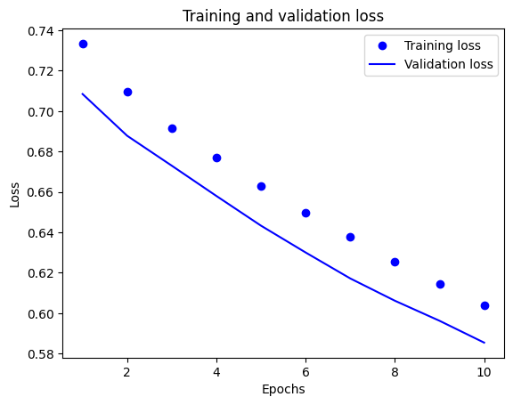

```python
#Plot Training and Validation loss
#learned from F.Chollet DLWP pg.81
import matplotlib.pyplot as plt

loss = history.history['loss']
val_loss = history.history['val_loss']
epochs = range(1, len(loss) + 1)
plt.plot(epochs, loss, 'bo', label='Training loss')
plt.plot(epochs, val_loss, 'b', label='Validation loss')
plt.title('Training and validation loss')
plt.xlabel('Epochs')
plt.ylabel('Loss')
plt.legend()
plt.show()
```

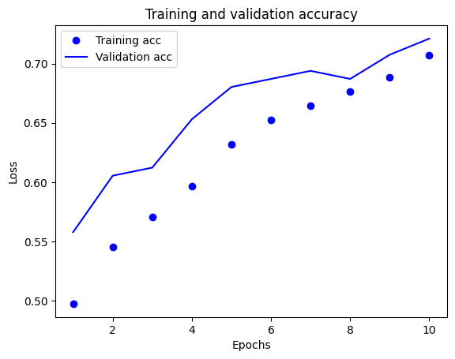

```python
#Plot Training and Validation loss
#learned from F.Chollet DLWP pg.82

acc = history.history['accuracy']
val_acc = history.history['val_accuracy']
plt.plot(epochs, acc, 'bo', label='Training acc')
plt.plot(epochs, val_acc, 'b', label='Validation acc')
plt.title('Training and validation accuracy')
plt.xlabel('Epochs')
plt.ylabel('Loss')
plt.legend()
plt.show()
```

## Baseline Model Results:

The first baseline model has done much better than the 50% coin flip baseline. The model has about 72 percent validation and training accuracy, it does however have about 60 percent training and validation loss. Reviewing the graphs drawn it seems quite clear that the model is underfitting and could definitely be improved with possibly more layers, greater output units and possibly other parameter adjustments.

## Developing an overfitting model

Now we shall develop a model that overfits. This model can then be adjusted after to fine tune to make a the best model we can develop.

```python
model_1 = models.Sequential()

model_1.add(layers.Input(shape=(X_train.shape[1])))

#2 hidden layers with now 64 output units
model_1.add(layers.Dense(64, activation='relu'))

model_1.add(layers.Dense(64, activation='relu'))

model_1.add(layers.Dense(1, activation='sigmoid'))

#still using binary crossentropy for loss
model_1.compile(optimizer='rmsprop', loss='binary_crossentropy', metrics=['accuracy'])

# training the model now with 100 epochs and 32 batch size
history = model_1.fit(X_train, y_train, epochs=100, batch_size=32, validation_split=0.2)
```

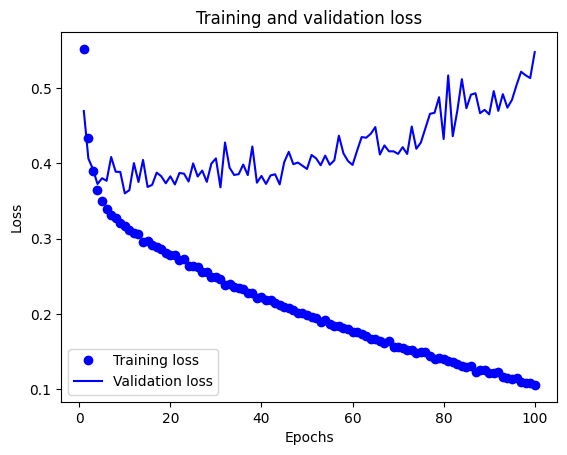

```python
loss = history.history['loss']
val_loss = history.history['val_loss']
epochs = range(1, len(loss) + 1)
plt.plot(epochs, loss, 'bo', label='Training loss')
plt.plot(epochs, val_loss, 'b', label='Validation loss')
plt.title('Training and validation loss')
plt.xlabel('Epochs')
plt.ylabel('Loss')
plt.legend()
plt.show()
```

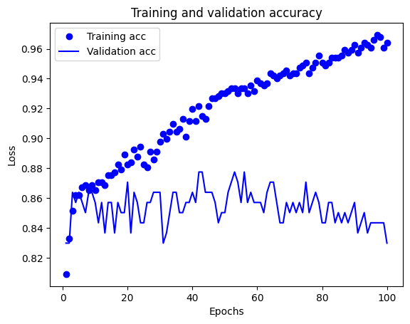

```python
acc = history.history['accuracy']
val_acc = history.history['val_accuracy']
plt.plot(epochs, acc, 'bo', label='Training acc')
plt.plot(epochs, val_acc, 'b', label='Validation acc')
plt.title('Training and validation accuracy')
plt.xlabel('Epochs')
plt.ylabel('Loss')
plt.legend()
plt.show()
```

## Overfitting Results:

Looking at the results this new model shows definite overfitting. The training accuracy reaches a mighty 96% and the training loss is all the way down to 0.1. However the validation values do fall off and degrade quite a lot, with validation accuracy at only about 83% and the validation loss at an abyssmal 0.55. Clearly we have gone over the other end as we attempted to do.

## Regularising and tuning the model:

Now we can finally tune the model into the best performing version possible. Looking back at the graph data of the previous model it looks like at around the 50 epoch mark is when the validation begins degrading, so we will try stick to 50 epochs as a start.

```python
model_2 = models.Sequential()

model_2.add(layers.Input(shape=(X_train.shape[1])))

model_2.add(layers.Dense(64, activation='relu'))

model_2.add(layers.Dense(64, activation='relu'))

model_2.add(layers.Dense(1, activation='sigmoid'))

model_2.compile(optimizer='rmsprop', loss='binary_crossentropy', metrics=['accuracy'])

# reduced to only 50 epochs
history = model_2.fit(X_train, y_train, epochs=50, batch_size=32, validation_split=0.2)
```

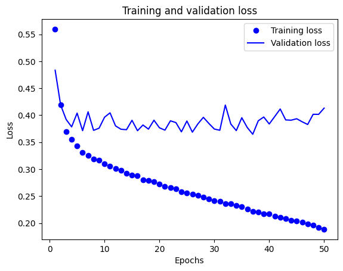

```python
loss = history.history['loss']
val_loss = history.history['val_loss']
epochs = range(1, len(loss) + 1)
plt.plot(epochs, loss, 'bo', label='Training loss')
plt.plot(epochs, val_loss, 'b', label='Validation loss')
plt.title('Training and validation loss')
plt.xlabel('Epochs')
plt.ylabel('Loss')
plt.legend()
plt.show()
```

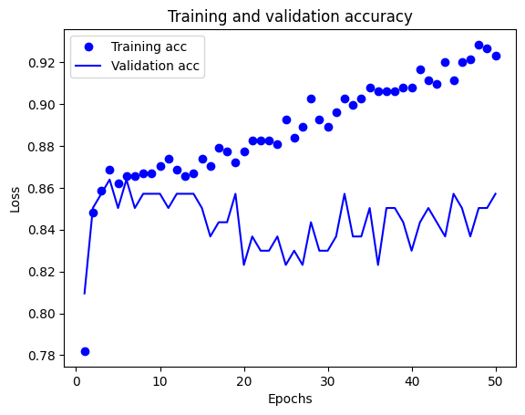

```python
acc = history.history['accuracy']
val_acc = history.history['val_accuracy']
plt.plot(epochs, acc, 'bo', label='Training acc')
plt.plot(epochs, val_acc, 'b', label='Validation acc')
plt.title('Training and validation accuracy')
plt.xlabel('Epochs')
plt.ylabel('Loss')
plt.legend()
plt.show()
```

The results have seemed to improve, but overfitting still seems to be a problem. This time we will also adjust the hidden layers output values and also try the adam optimiser.

```python
model_3 = models.Sequential()

model_3.add(layers.Input(shape=(X_train.shape[1])))

# reduce hidden layers to 32 output units
model_3.add(layers.Dense(32, activation='relu'))

model_3.add(layers.Dense(32, activation='relu'))

model_3.add(layers.Dense(1, activation='sigmoid'))

# using adam optimizer this time
model_3.compile(optimizer='adam', loss='binary_crossentropy', metrics=['accuracy'])

history = model_3.fit(X_train, y_train, epochs=50, batch_size=32, validation_split=0.2)
```

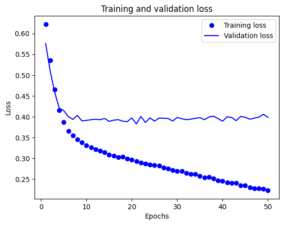

```python
loss = history.history['loss']
val_loss = history.history['val_loss']
epochs = range(1, len(loss) + 1)
plt.plot(epochs, loss, 'bo', label='Training loss')
plt.plot(epochs, val_loss, 'b', label='Validation loss')
plt.title('Training and validation loss')
plt.xlabel('Epochs')
plt.ylabel('Loss')
plt.legend()
plt.show()
```

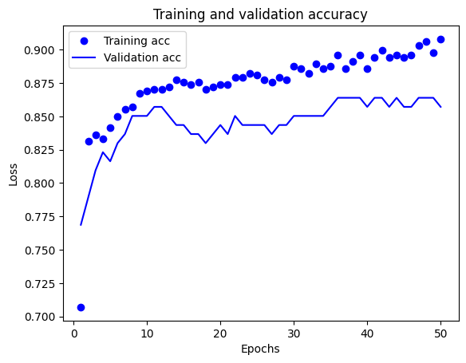

```python
acc = history.history['accuracy']
val_acc = history.history['val_accuracy']
plt.plot(epochs, acc, 'bo', label='Training acc')
plt.plot(epochs, val_acc, 'b', label='Validation acc')
plt.title('Training and validation accuracy')
plt.xlabel('Epochs')
plt.ylabel('Loss')
plt.legend()
plt.show()
```

It has not seemed to improve much from the previous model. Now I will add some dropout layers to try and reduce the overfitting and large loss amounts.

```python
model_4 = models.Sequential()

model_4.add(layers.Input(shape=(X_train.shape[1])))


model_4.add(layers.Dense(32, activation='relu'))
model_4.add(layers.Dropout(0.2)) #dropout layers added
model_4.add(layers.Dense(32, activation='relu'))
model_4.add(layers.Dropout(0.2))
model_4.add(layers.Dense(1, activation='sigmoid'))

# using adam optimizer this time
model_4.compile(optimizer='adam', loss='binary_crossentropy', metrics=['accuracy'])

history = model_4.fit(X_train, y_train, epochs=50, batch_size=32, validation_split=0.2)
```

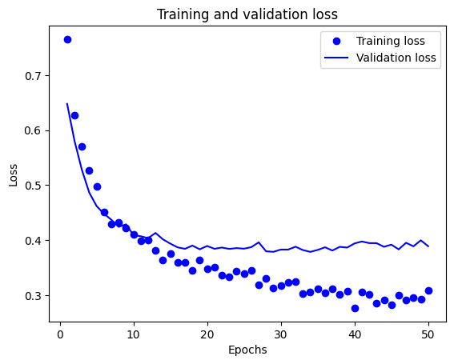

```python
loss = history.history['loss']
val_loss = history.history['val_loss']
epochs = range(1, len(loss) + 1)
plt.plot(epochs, loss, 'bo', label='Training loss')
plt.plot(epochs, val_loss, 'b', label='Validation loss')
plt.title('Training and validation loss')
plt.xlabel('Epochs')
plt.ylabel('Loss')
plt.legend()
plt.show()
```